# Case Study: Financial Data

Basel R Bootcamp, July 2018 [www.therbootcamp.com](https://therbootcamp.github.io) [@therbootcamp](https://twitter.com/therbootcamp)

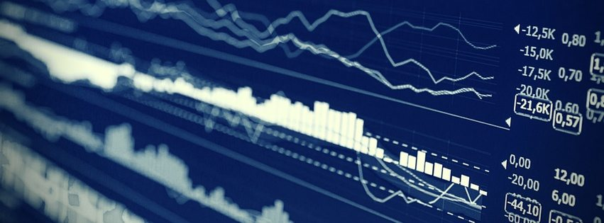

[source](https://www.techemergence.com/wp-content/uploads/2016/08/Machine-Learning-in-Finance.jpg)

### Overview

In this case study, you will analyse historic data of three major stock indices, the **Dow Jones**, the **DAX**, and the **Nikkei**, and the exchange rates between the **US dollar**, the **Euro**, and the **Yen**. Using this data, you will address several questions.

1. How large was the impact of the recent financial crisis on the respective stock markets?
2. How correlated is the development between the stock markets?
3. What is the relationship between stock market returns and exchange rates?

To address these questions, you will import several data files, while tuning import parameters to match the idiosyncrasies of the data. You will merge the data files into a single data frame, and mutate the data to reflect changes in index price and exchange rate. You will analyze correlations of stock indices among themselves and to exchange rates and create illustrative plots for each of the analyses.

Below you will find several tasks that will guide you through these steps. For the most part these tasks require you to make use of what you have learned in the sessions **Data I/O**, **Data Wrangling**, and **Statistics**. However, they will also go beyond what you have learned, in particular when it comes to plotting. In those cases, the tasks will provide the necessary code and guidance.

### Datasets

```r
library(tidyverse)
library(haven)
```

[output not shown]

Variables of data sets `^DJI.csv`, `^GDAXI.csv`, `^N225.csv`

| Variable | Description |
| --- | --- |
| Date | Current day |
| Open | Day’s price when the stock exchange opened |
| High | Day’s highest price |
| Low | Day’s lowest price |
| Close | Day’s closing price |
| Adj Close | Adjusted closing price that has been amended to include any distributions and corporate actions that occurred at any time prior to the next day’s open |

Variables of data sets “euro-dollar.txt”, “yen-dollar.txt”

| Variable | Description |
| --- | --- |
| Date (currently unnamed) | Current day |
| Rate (currently unnamed) | Day’s exchange rate in terms of 1 US Dollar. E.g., a value of .75 means that the respective currency is worth a fraction of .75 of 1 US Dollar |

# Tasks

## B - Data I/O

1. In this practical, you will load three external datasets `\^DJI.csv`, `\^GDAXI.csv`, and `\^N225.csv`. However, two of these data files are a bit messy. Specifically, `\^GDAXI.csv` and `\^N225.csv` use a specific character string to represent missings in the data. To identify the NA-character string in the data open one of them in a text viewer, (via RStudio or via, e.g., *textedit*). Do you see the string value that indicates missing data?.
2. Once you know what string value indicates missing data, us the `read_csv()` function to load in the stock index data sets, “^DJI.csv”, “^GDAXI.csv”, and “^N225.csv”, from your `1_Data` folder. In so doing, set an explicit `na`-argument to account for the fact that “^GDAXI.csv” “^N225.csv” use a specific character string to represent missings in the data.

```r
# Load index data from local data folder
dow <- read_csv(file = '1_Data/^DJI.csv')
dax <- read_csv(file = '1_Data/^GDAXI.csv', na = 'null')
nik <- read_csv(file = '1_Data/^N225.csv', na = 'null')
```

3. Load in the exchange rate data sets, `euro-dollar.txt` and `yen-dollar.txt`, from the `1_Data` folder as two new objects called `eur_usd` and `yen_usd`. To do this, use the `read_delim()`-function and `\t` as the `delim`-argument. This tells R that the data is tab-delimited.

```r
# Load exchange rate data from local data folder
eur_usd <- read_delim(file = '1_Data/euro-dollar.txt', delim = '\t')
yen_usd <- read_delim(file = '1_Data/yen-dollar.txt', delim = '\t')
```

4. Print the `eur_usd` and `yen_usd` objects. Are all the data types and variable names correct?

```r
# Print exchange rates
eur_usd
```

```
# A tibble: 6,545 x 2
   `04 Jan 1999` `1.186669`
   <chr>              <dbl>
 1 05 Jan 1999         1.18
 2 06 Jan 1999         1.16
 3 07 Jan 1999         1.17
 4 08 Jan 1999         1.16
 5 11 Jan 1999         1.15
 6 12 Jan 1999         1.16
 7 13 Jan 1999         1.17
 8 14 Jan 1999         1.17
 9 15 Jan 1999         1.16
10 18 Jan 1999         1.16
# ... with 6,535 more rows
```

```r
yen_usd
```

```
# A tibble: 8,764 x 2
   `02 Jan 1990` `0.006838`
   <chr>              <dbl>
 1 03 Jan 1990      0.00686
 2 04 Jan 1990      0.00698
 3 05 Jan 1990      0.00695
 4 08 Jan 1990      0.00694
 5 09 Jan 1990      0.00689
 6 10 Jan 1990      0.00688
 7 11 Jan 1990      0.00688
 8 12 Jan 1990      0.00688
 9 16 Jan 1990      0.00687
10 17 Jan 1990      0.00687
# ... with 8,754 more rows
```

5. There’s something wrong, right? First, we want the columns to be called `Date` and `Rate` (and not be taken from the first row). To fix this, load the data again with the following additional arguments:
- First, include the `col_names`-argument and assign to it a vector that contains the variable names.
- Second, ensure that the `Date`-variable is of type `date`. To achieve this, use the `parse_date` function with the argument `format = '%d %b %Y'`. This specifies the exact format the dates are formatted in, and overwrite the existing `Date`-variable.

```r
# Load exchange rate data from local data folder
eur_usd <- read_delim(file = '1_Data/euro-dollar.txt', delim = '\t', col_names = c('Date', 'Rate'))
yen_usd <- read_delim(file = '1_Data/yen-dollar.txt', delim = '\t', col_names = c('Date', 'Rate'))
```

6. Finally you want to make sure that the variable `Date` is actually of type `date`. Fix this using the `parse_date()` function with `format = '%d %b %Y'`. This specifies the exact format the dates are formatted in. Overwrite the existing `Date`-variable.

```r
# change Date to date type
eur_usd$Date <- parse_date(eur_usd$Date, format = '%d %b %Y')
yen_usd$Date <- parse_date(yen_usd$Date, format = '%d %b %Y')
```

7. Ok your datasets should be correct now! Get a first impression of the them using `print()`, `typeof()` and `str()`. What type are the data objects and what variables do they contain?

```r
# Inspect data
typeof(dow) ; str(dow)
```

```
[1] "list"
```

```
Classes 'tbl_df', 'tbl' and 'data.frame':   8364 obs. of  7 variables:
 $ Date     : Date, format: "1985-01-29" "1985-01-30" ...
 $ Open     : num  1278 1297 1283 1277 1272 ...
 $ High     : num  1295 1305 1293 1286 1295 ...
 $ Low      : num  1267 1279 1273 1270 1269 ...
 $ Close    : num  1293 1288 1287 1278 1290 ...
 $ Adj Close: num  1293 1288 1287 1278 1290 ...
 $ Volume   : int  13560000 16820000 14070000 10980000 11630000 13800000 14610000 11440000 8000000 12600000 ...
 - attr(*, "spec")=List of 2
  ..$ cols   :List of 7
  .. ..$ Date     :List of 1
  .. .. ..$ format: chr ""
  .. .. ..- attr(*, "class")= chr  "collector_date" "collector"
  .. ..$ Open     : list()
  .. .. ..- attr(*, "class")= chr  "collector_double" "collector"
  .. ..$ High     : list()
  .. .. ..- attr(*, "class")= chr  "collector_double" "collector"
  .. ..$ Low      : list()
  .. .. ..- attr(*, "class")= chr  "collector_double" "collector"
  .. ..$ Close    : list()
  .. .. ..- attr(*, "class")= chr  "collector_double" "collector"
  .. ..$ Adj Close: list()
  .. .. ..- attr(*, "class")= chr  "collector_double" "collector"
  .. ..$ Volume   : list()
  .. .. ..- attr(*, "class")= chr  "collector_integer" "collector"
  ..$ default: list()
  .. ..- attr(*, "class")= chr  "collector_guess" "collector"
  ..- attr(*, "class")= chr "col_spec"
```

```r
typeof(dax) ; str(dax)
```

```
[1] "list"
```

```
Classes 'tbl_df', 'tbl' and 'data.frame':   7811 obs. of  7 variables:
 $ Date     : Date, format: "1987-12-30" "1987-12-31" ...
 $ Open     : num  1005 NA NA 956 996 ...
 $ High     : num  1005 NA NA 956 996 ...
 $ Low      : num  1005 NA NA 956 996 ...
 $ Close    : num  1005 NA NA 956 996 ...
 $ Adj Close: num  1005 NA NA 956 996 ...
 $ Volume   : int  0 NA NA 0 0 0 0 0 0 0 ...
 - attr(*, "spec")=List of 2
  ..$ cols   :List of 7
  .. ..$ Date     :List of 1
  .. .. ..$ format: chr ""
  .. .. ..- attr(*, "class")= chr  "collector_date" "collector"
  .. ..$ Open     : list()
  .. .. ..- attr(*, "class")= chr  "collector_double" "collector"
  .. ..$ High     : list()
  .. .. ..- attr(*, "class")= chr  "collector_double" "collector"
  .. ..$ Low      : list()
  .. .. ..- attr(*, "class")= chr  "collector_double" "collector"
  .. ..$ Close    : list()
  .. .. ..- attr(*, "class")= chr  "collector_double" "collector"
  .. ..$ Adj Close: list()
  .. .. ..- attr(*, "class")= chr  "collector_double" "collector"
  .. ..$ Volume   : list()
  .. .. ..- attr(*, "class")= chr  "collector_integer" "collector"
  ..$ default: list()
  .. ..- attr(*, "class")= chr  "collector_guess" "collector"
  ..- attr(*, "class")= chr "col_spec"
```

```r
typeof(nik) ; str(nik)
```

```
[1] "list"
```

```
Classes 'tbl_df', 'tbl' and 'data.frame':   13722 obs. of  7 variables:
 $ Date     : Date, format: "1965-01-05" "1965-01-06" ...
 $ Open     : num  1258 1264 1274 1286 NA ...
 $ High     : num  1258 1264 1274 1286 NA ...
 $ Low      : num  1258 1264 1274 1286 NA ...
 $ Close    : num  1258 1264 1274 1286 NA ...
 $ Adj Close: num  1258 1264 1274 1286 NA ...
 $ Volume   : int  0 0 0 0 NA 0 0 0 NA 0 ...
 - attr(*, "spec")=List of 2
  ..$ cols   :List of 7
  .. ..$ Date     :List of 1
  .. .. ..$ format: chr ""
  .. .. ..- attr(*, "class")= chr  "collector_date" "collector"
  .. ..$ Open     : list()
  .. .. ..- attr(*, "class")= chr  "collector_double" "collector"
  .. ..$ High     : list()
  .. .. ..- attr(*, "class")= chr  "collector_double" "collector"
  .. ..$ Low      : list()
  .. .. ..- attr(*, "class")= chr  "collector_double" "collector"
  .. ..$ Close    : list()
  .. .. ..- attr(*, "class")= chr  "collector_double" "collector"
  .. ..$ Adj Close: list()
  .. .. ..- attr(*, "class")= chr  "collector_double" "collector"
  .. ..$ Volume   : list()
  .. .. ..- attr(*, "class")= chr  "collector_integer" "collector"
  ..$ default: list()
  .. ..- attr(*, "class")= chr  "collector_guess" "collector"
  ..- attr(*, "class")= chr "col_spec"
```

```r
typeof(eur_usd) ; str(eur_usd)
```

```
[1] "list"
```

```
Classes 'tbl_df', 'tbl' and 'data.frame':   6546 obs. of  2 variables:
 $ Date: Date, format: "1999-01-04" "1999-01-05" ...
 $ Rate: num  1.19 1.18 1.16 1.17 1.16 ...
 - attr(*, "spec")=List of 2
  ..$ cols   :List of 2
  .. ..$ Date: list()
  .. .. ..- attr(*, "class")= chr  "collector_character" "collector"
  .. ..$ Rate: list()
  .. .. ..- attr(*, "class")= chr  "collector_double" "collector"
  ..$ default: list()
  .. ..- attr(*, "class")= chr  "collector_guess" "collector"
  ..- attr(*, "class")= chr "col_spec"
```

```r
typeof(yen_usd) ; str(yen_usd)
```

```
[1] "list"
```

```
Classes 'tbl_df', 'tbl' and 'data.frame':   8765 obs. of  2 variables:
 $ Date: Date, format: "1990-01-02" "1990-01-03" ...
 $ Rate: num  0.00684 0.00686 0.00698 0.00695 0.00694 ...
 - attr(*, "spec")=List of 2
  ..$ cols   :List of 2
  .. ..$ Date: list()
  .. .. ..- attr(*, "class")= chr  "collector_character" "collector"
  .. ..$ Rate: list()
  .. .. ..- attr(*, "class")= chr  "collector_double" "collector"
  ..$ default: list()
  .. ..- attr(*, "class")= chr  "collector_guess" "collector"
  ..- attr(*, "class")= chr "col_spec"
```

## C - Data Wrangling

1. Now it’s time to create a single data frame that contains the data from all five datasets including only the variables containing the dates (`Date`), the stock index (unadjusted) closing prices (`Close`), and the exchange rates. Do this by *piping* (i.e., using `%>%`) together several `inner_join()`-functions, joining the data sets one-by-one using the `Date` variable. Note, in joining two data sets you can control the naming of overlapping variable names using the `suffix`-argument of the `inner_join()`-function. Observe that `inner_join()` takes care of the fact that different dates are available in each of the data sets by only retaining dates for which all data sets provide data on.
2. At the end, rename the variables appropriately using the `rename()`-function.

```r
# create single data frame
data = dow %>% select('Date','Close') %>%
  inner_join(dax %>% select('Date','Close'), by = 'Date', suffix = c('_dow','_dax')) %>%
  inner_join(nik %>% select('Date','Close'), by = 'Date') %>%
  inner_join(eur_usd, by = 'Date') %>%
  inner_join(yen_usd, by = 'Date', suffix = c('_eur','_yen')) %>%
  rename('Close_nik' = 'Close')
```

3. Create new variables containing the change in index price and exchange rate for each variable using the `mutate`-function(). To compute the change, use the `diff()`-function. Since `diff()` will return `n - 1` change values, add an `NA` at the first position of the change variable à la `c(NA, diff(my_variable))`.

```r
# create variables representing day-to-day changes
data = data %>% mutate(
  Close_dow_change = c(NA, diff(Close_dow)),
  Close_dax_change = c(NA, diff(Close_dax)),
  Close_nik_change = c(NA, diff(Close_nik)),
  Rate_eur_change = c(NA, diff(Rate_eur)),
  Rate_yen_change = c(NA, diff(Rate_yen))
)
```

4. Create a variable containing only the year of the date variable using `mutate()` and `year()` from the `lubridate`-package (which is part of the `tidyverse`).

```r
# load lubridate
library(lubridate)
# create year variable
data = data %>% mutate(year = year(Date))
```

5. Currently your data is in the “wide” format. Let’s convert it to the long format, in which variables occupy different rows rather than columns, using the `gather()`-function from the `tidyr`-package (also part of the `tidyverse`). To do this use the command below to create the `long_data` data frame. You may have to (or want to) change the object/variable names. The first two arguments (given we used *pipes*) to the `gather`-function specify the names of the new variables, the third and fourth specify the names of the variable containing the dates and years with a leading hyphen. (Check out the example in the `?gather`-help file).

```r
# create long version of data frame
long_data <- data %>% gather(variable, value, -Date, -year)
```

6. Print your `long_data` object. How does it compare to your original `data` object?

## D - Statistics (& Plotting)

1. Using the following code, plot the price development of the three stock indices using the following command (using the long data object). The code uses `ggplot2`, which you will be introduced to on the second weekend of the course. For the code to work, you may have to adjust the object and variable names to match the ones in your data frame. Inspecting the plot, do you see a significant drop anywhere?

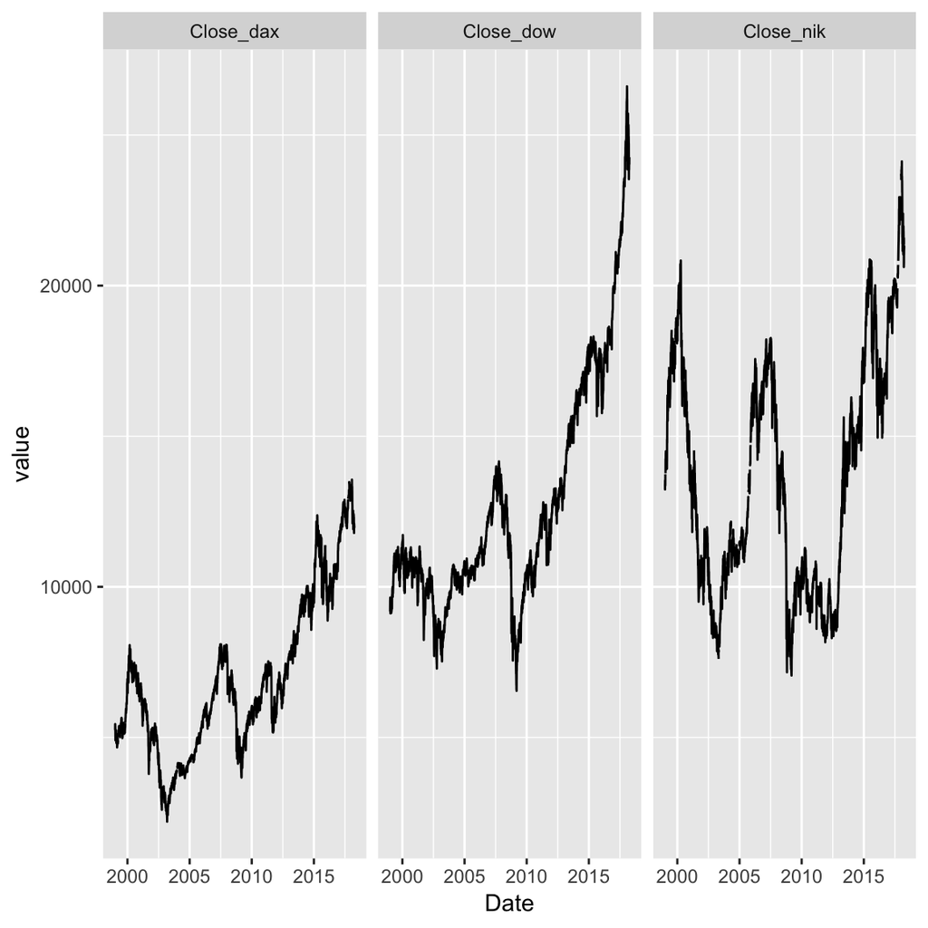

```r
# create long version of data frame
temp_data <- long_data %>%
  filter(variable %in% c("Close_dow", "Close_dax", "Close_nik"))

ggplot(data = temp_data,
       mapping = aes(x = Date, y = value)) +
  geom_line() +
  facet_grid(~variable)
```

2. Calculate the overall stock index price change per year. To do this, ise `group_by()`, `summarise()`, and `sum()` on the stock index change variables. Remember there were `NA`’s in two of the stock index price variables. When was the biggest drop in stock index prices?

```r
# calculate aggregate change per year
aggregate_change <- data %>%
  group_by(year) %>%
  summarize(
    mean_dow_change = sum(Close_dow_change),
    mean_dax_change = sum(Close_dax_change, na.rm = T),
    mean_nik_change = sum(Close_nik_change, na.rm = T)
)
aggregate_change
```

```
# A tibble: 20 x 4
    year mean_dow_change mean_dax_change mean_nik_change
   <dbl>           <dbl>           <dbl>           <dbl>
 1  1999            NA             1529.          5903.
 2  2000          -709.            -455.         -5561.
 3  2001          -766.           -1254.         -4436.
 4  2002         -1680.           -2112.         -2235.
 5  2003          2112.             718.           327.
 6  2004           329.             180.          1335.
 7  2005           -65.5           1108.          3219.
 8  2006          1746.            1189.          1504.
 9  2007           903.            1470.         -1918.
10  2008         -4697.           -3257.         -6448.
11  2009          1880.            1147.          1513.
12  2010          1021.             957.          -318.
13  2011           648.           -1016.         -1774.
14  2012           721.            1714.          1940.
15  2013          3566.            1940.          5896.
16  2014          1479.             253.          1159.
17  2015          -379.             937.          1583.
18  2016          2159.             738.            80.7
19  2017          4957.            1266.          3439.
20  2018          -455.            -960.         -2395.
```

3. Now that you know when the biggest drop occured, let’s find out which stock index suffered the biggest loss? To do this, compare the overall losses to the index price on the first trading day of that year. To do this, first identify the first date available for that year and then `filter()` the data based on the respective character string to retrieve that day’s closing prices. Then divide the overall stock price change by that years first closing price. Which stock index suffered the greatest relative loss?

```r
aggregate_change %>%
  filter(year == 2008) %>%
  select(-1) / data %>%
  filter(Date == "2008-01-04") %>%
  select(Close_dow, Close_dax, Close_nik)
```

```
  mean_dow_change mean_dax_change mean_nik_change
1          -0.367          -0.417          -0.439
```

4. One driver behind the results observed for the last two tasks is that modern financial markets are closely intertwined, to the extent that a change in one market can bring about a change in the markets. Evaluate this aspect of financial markets by correlating the stock index change variables among each other using `cor()`. Note that `cor()` can take a data frame as an argument to produce the full correlation matrix among all variables. Also, don’t forget about the `NA`s - there is an argument for `cor()` to deal with them. How closely are the stock indices related and which ones are most closely related?

```r
data %>%
  select(Close_dow_change, Close_dax_change, Close_nik_change) %>%
  cor(., use = 'complete.obs')
```

```
                 Close_dow_change Close_dax_change Close_nik_change
Close_dow_change            1.000            0.570            0.169
Close_dax_change            0.570            1.000            0.318
Close_nik_change            0.169            0.318            1.000
```

5. Evaluate the stability of the relationships between financial markets by analyzing the correlations for each year. Note that here have to specify each pairwise correlation separately in order to `summarise()` the correlation for each year (rather than computing the entire correlation matrix).

```r
data %>%
  group_by(year) %>%
  summarize(
    cor_dow_dax = cor(Close_dow_change, Close_dax_change, use = 'complete.obs'),
    cor_dow_nik = cor(Close_dow_change, Close_nik_change, use = 'complete.obs'),
    cor_dax_nik = cor(Close_dax_change, Close_nik_change, use = 'complete.obs')
)
```

```
# A tibble: 20 x 4
    year cor_dow_dax cor_dow_nik cor_dax_nik
   <dbl>       <dbl>       <dbl>       <dbl>
 1  1999       0.453      0.0730       0.192
 2  2000       0.308     -0.0519       0.195
 3  2001       0.667      0.255        0.287
 4  2002       0.654      0.196        0.236
 5  2003       0.695      0.127        0.249
 6  2004       0.468      0.166        0.344
 7  2005       0.390      0.0625       0.327
 8  2006       0.594      0.100        0.266
 9  2007       0.537      0.0874       0.394
10  2008       0.613      0.212        0.527
11  2009       0.732      0.175        0.260
12  2010       0.695      0.255        0.329
13  2011       0.796      0.185        0.351
14  2012       0.725      0.212        0.325
15  2013       0.566      0.161        0.256
16  2014       0.567      0.149        0.176
17  2015       0.538      0.254        0.295
18  2016       0.605      0.214        0.387
19  2017       0.554      0.367        0.395
20  2018       0.378      0.108        0.481
```

6. Another important index of the financial markets is the exchange rate to other currencies. Generally, it is assumed that a strong economy translates in both a strong stock index and a strong currency relative to other currencies. First, evaluate whether changes in exchange rates correlate with each other the same way that stock indices do.

```r
data %>%
  select(Rate_eur_change, Rate_yen_change) %>%
  cor(., use = 'complete.obs')
```

```
                Rate_eur_change Rate_yen_change
Rate_eur_change           1.000           0.391
Rate_yen_change           0.391           1.000
```

7. Now evaluate whether exchange rates vary as a function of the difference between stock indices. For example, does a large difference between Dow Jones and DAX translate into a strong Dollar relative to the EURO? Based on the above intuition this should be the case. However, economic theory has also produced an alternative hypothesis. That is, foreign investors who benefit from a rise in stock index price may be motivated to sell their holdings and exchange them for their own currency to maintain a neutral position. This would, in effect, depreciate the currency at the same time as the stock index is outperforming, thus producing a negative relationship. What do you think? Ask the data.

```r
data %>%
  summarize(
    cor_dow_dax = cor(Close_dow - Close_dax, Rate_eur, use = 'complete.obs'),
    cor_dow_nik = cor(Close_dow - Close_nik, Rate_yen, use = 'complete.obs')
  )
```

```
# A tibble: 1 x 2
  cor_dow_dax cor_dow_nik
        <dbl>       <dbl>
1      0.0869       0.569
```

8. Now, evaluate the stability of the above relationship for each year separately? Can you make out a stable pattern? No? I guess it depends.

```r
data %>%
  group_by(year) %>%
  summarize(
    cor_dow_dax = cor(Close_dow - Close_dax, Rate_eur, use = 'complete.obs'),
    cor_dow_nik = cor(Close_dow - Close_nik, Rate_yen, use = 'complete.obs')
  )
```

```
# A tibble: 20 x 3
    year cor_dow_dax cor_dow_nik
   <dbl>       <dbl>       <dbl>
 1  1999      -0.639     -0.501
 2  2000      -0.222     -0.479
 3  2001      -0.393     -0.221
 4  2002       0.162     -0.287
 5  2003       0.772     -0.320
 6  2004       0.253      0.427
 7  2005       0.831      0.862
 8  2006       0.776      0.0745
 9  2007      -0.136      0.824
10  2008       0.825      0.788
11  2009       0.837      0.740
12  2010       0.714      0.932
13  2011      -0.334      0.459
14  2012      -0.248      0.727
15  2013      -0.235      0.898
16  2014      -0.856      0.781
17  2015       0.601      0.819
18  2016      -0.108      0.831
19  2017       0.784      0.629
20  2018       0.470      0.792
```

### References

https://www.weforum.org/agenda/2015/07/whats-the-relationship-between-stock-returns-and-exchange-rates/ http://www.faz.net/aktuell/finanzen/aktien/eine-geschichte-des-dax-die-wichtigsten-ereignisse-12970011.html